# Selected Sections from Chapter 10: 10.11

© Scott Robison 2021 all rights reserved.

## Likelihood Ratio Tests

> Start by [Reading](https://github.com/chqngh-berkeley/personal/blob/master/Mathematical%20Statistics%20-%207th%20Edition%20-%20Wackerly.pdf) pages 549-554 from the text.

### Finding the Most Powerful Test: Likelihood Ratio Tests

We have seen that the Neyman–Pearson Lemma will give us the critical value (and therefore it’s distribution) of simple hypothesis tests. But what about for composite hypothesis testing?

Notation. We’ll assume that the probability density (or mass) function of $X$ is $f(x|\theta)$ where $\theta$ represents one or more unknown parameters. Then:

1. Let $\Omega$ (Greek letter “omega”) denote the total possible parameter space of $\theta$, that is, the set of all possible values of $\theta$ as specified in totality in the null and alternative hypotheses.
2. Let $H_0:\theta\in\omega$ denote the null hypothesis where $\omega$ (Greek letter “omega”) is a subset of the parameter space $\Omega$.
3. Let $H_a:\theta\in \omega '$ denote the alternative hypothesis where $\omega '$ is the complement of $\omega$ with respect to the parameter space $\Omega$.

If the total parameter space of the mean $\mu$ is $\Omega = \{\mu: -\infty < mu < \infty\}$ and the null hypothesis is specified as $H_0: \mu = 3$, how should we specify the alternative hypothesis so that the alternative parameter space is the complement of the null parameter space?

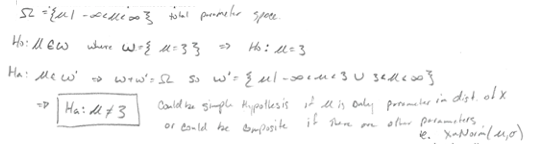

If the alternative hypothesis is $H_a: \mu > 3$, how should we (technically) specify the null hypothesis so that the null parameter space is the complement of the alternative parameter space?

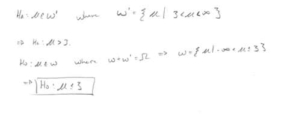

**Definition.** Let:

1. $L(\widehat{\omega})$ denote the maximum of the likelihood function with respect to $\theta$ when $\theta$ is in the null parameter space $\omega$.
2. $L(\widehat{\Omega})$ denote the maximum of the likelihood function with respect to $\theta$ when $\theta$ is in the entire parameter space $\Omega$.

Then, the **likelihood ratio is the quotient**:

$$\lambda=\frac{L(\widehat{\omega}) }{L(\widehat{\Omega})}$$

And, to test the null hypothesis $H_0:\theta\in\omega$ against the alternative hypothesis $H_a:\theta\in\omega'$, the critical region for the likelihood ratio test is the set of sample points for which:

$$\lambda=\frac{L(\widehat{\omega}) }{L(\widehat{\Omega})}\le k$$

where $0 < \lambda < 1\Rightarrow 0 < k < 1$, and $k$ is selected so that the test has a desired significance level $\alpha$.

Looking for [solved notes?](https://people.ucalgary.ca/~sarobiso/323/text%20soltutions/Finding%20the%20Most%20Powerful%20Test%20Likelihood%20Ratio%20Tests.pdf)

### Example 1

A food processing company packages honey in small glass jars. Each jar is supposed to contain 10 fluid ounces of the sweet and gooey good stuff. Previous experience suggests that the volume $X$, the volume in fluid ounces of a randomly selected jar of the company’s honey is normally distributed with a known variance of $\sigma^2=2$. Derive the likelihood ratio test for testing, at a significance level of $\alpha = 0.05$, the null hypothesis $H_0: \mu = 10$ against the alternative hypothesis $H_a: \mu\ne 10$.

### Solution

[video not shown]

### Example 2

Let $X_1,X_2,· · · ,X_n$ represent a random sample from a normal distribution. That is, $Xi \sim Normal(\mu,\sigma^2)$. This sample is used to test the hypothesis

$$\begin{align}
H_0:\mu=\mu_0, & & H_a:\mu=\mu_A,(\mu_A >\mu_0)\\
\end{align}$$

Find the most powerful test.

### Solution

It turns out… we didn’t know it at the time… but every hypothesis test that we derived in the hypothesis testing section is a likelihood ratio test. Back then, we derived each test using distributional results of the relevant statistic(s), but we could have alternatively, and perhaps just as easily, derived the tests using the likelihood ratio testing method

> Please [**Practice**](https://github.com/chqngh-berkeley/personal/blob/master/Mathematical%20Statistics%20-%207th%20Edition%20-%20Wackerly.pdf) as many exercises from pages 554-556 as possible the odd questions have answers in the back of the text.

> This is where the real learning happens.